# Kestasioneran dalam Rataan dan Ragam

Nabil Naufal (G1401211008)

## Library yang digunakan

```r
library(ggplot2)
library(tsibble)
library(tseries)
library(MASS)
```

## Impor Data

```r
library(rio)
data <- import("https://raw.githubusercontent.com/mrnabilnaufal07/mpdw/main/Data/Data-Nabil.csv")

# MEngubah tipe data `Meninggal` menjadi time series
data$Meninggal = ts(data$Meninggal)
View(data)
die = data$Meninggal
```

### Plot *Time Series*

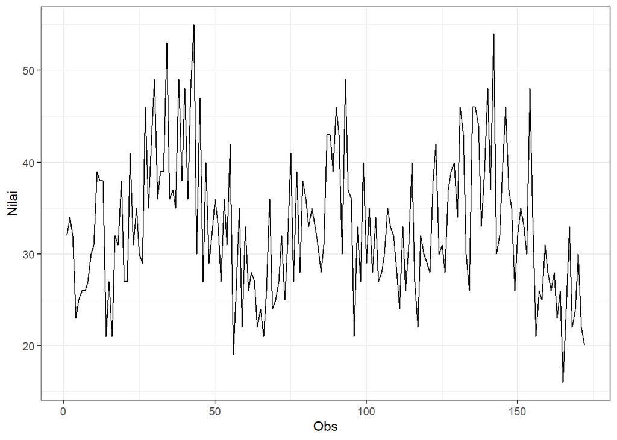

```r
plot<- data |>
  ggplot(aes(x = Periode, y = Meninggal)) + geom_line() + theme_bw() +
  xlab("Obs") + ylab("Nilai")
plot
```

Plot deret waktu di atas menunjukkan bahwa data tidak stasioner dalam rataan maupun ragam.

### Plot ACF

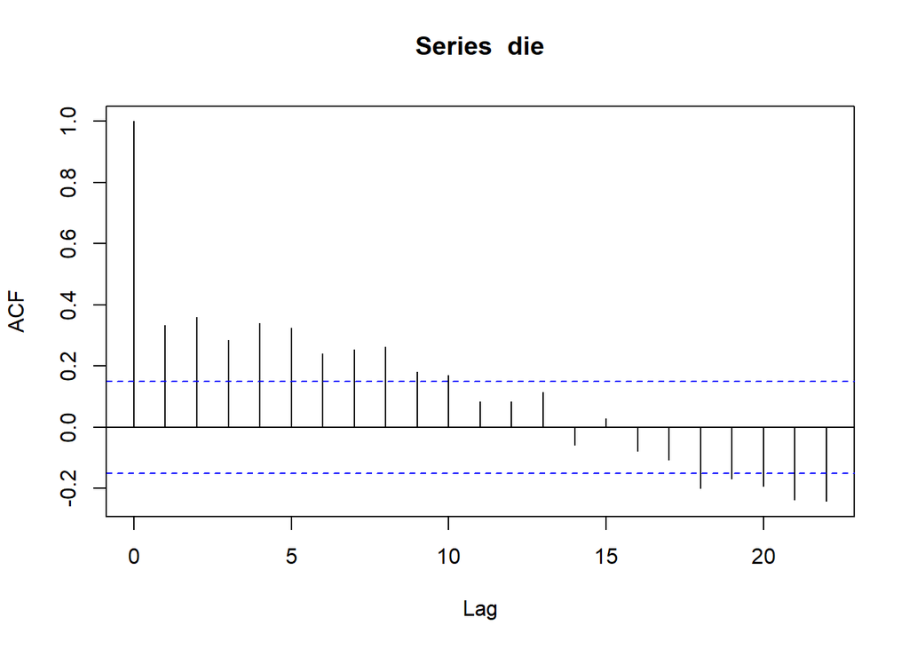

```r
acf(die)
```

Berdasarkan plot ACF, terlihat bahwa plot ACF pada data tersebut cenderung *tails off* dan lambat. Artinya data tidak stasioner dalam rataan.

### Uji ADF

```r
tseries::adf.test(die)
```

```
##
##  Augmented Dickey-Fuller Test
##
## data:  die
## Dickey-Fuller = -2.608, Lag order = 5, p-value = 0.3224
## alternative hypothesis: stationary
```

$H_0$ : Data tidak stasioner dalam rataan

$H_1$ : Data stasioner dalam rataan

Berdasarkan uji ADF tersebut, didapat *p-value* sebesar 0.3224 yang lebih besar dari taraf nyata 5% sehingga tidak tolak $H_0$ dan menandakan bahwa data tidak stasioner dalam rataan. Hal ini sesuai dengan hasil eksplorasi menggunakan plot time series dan plot ACF.

### Plot Box-Cox

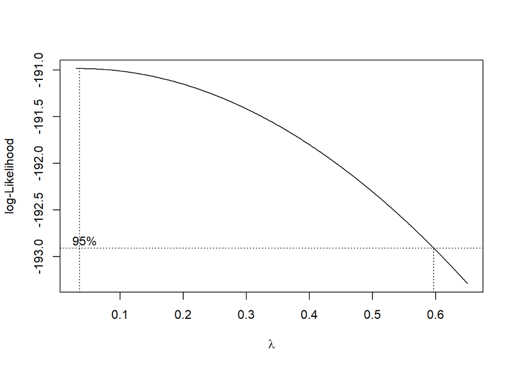

```r
n = length(die)
index <- seq(1:n)
bc = boxcox(die~index, lambda = seq(0.03,0.65,by=0.001))
```

```r
#Nilai Rounded Lambda
lambda <- bc$x[which.max(bc$y)]
lambda
```

```
## [1] 0.036
```

```r
#SK
bc$x[bc$y > max(bc$y) - 1/2 * qchisq(.95,1)]
```

```
##   [1] 0.030 0.031 0.032 0.033 0.034 0.035 0.036 0.037 0.038 0.039 0.040 0.041
##  [13] 0.042 0.043 0.044 0.045 0.046 0.047 0.048 0.049 0.050 0.051 0.052 0.053
##  [25] 0.054 0.055 0.056 0.057 0.058 0.059 0.060 0.061 0.062 0.063 0.064 0.065
##  [37] 0.066 0.067 0.068 0.069 0.070 0.071 0.072 0.073 0.074 0.075 0.076 0.077
##  [49] 0.078 0.079 0.080 0.081 0.082 0.083 0.084 0.085 0.086 0.087 0.088 0.089
##  [61] 0.090 0.091 0.092 0.093 0.094 0.095 0.096 0.097 0.098 0.099 0.100 0.101
##  [73] 0.102 0.103 0.104 0.105 0.106 0.107 0.108 0.109 0.110 0.111 0.112 0.113
##  [85] 0.114 0.115 0.116 0.117 0.118 0.119 0.120 0.121 0.122 0.123 0.124 0.125
##  [97] 0.126 0.127 0.128 0.129 0.130 0.131 0.132 0.133 0.134 0.135 0.136 0.137
## [109] 0.138 0.139 0.140 0.141 0.142 0.143 0.144 0.145 0.146 0.147 0.148 0.149
## [121] 0.150 0.151 0.152 0.153 0.154 0.155 0.156 0.157 0.158 0.159 0.160 0.161
## [133] 0.162 0.163 0.164 0.165 0.166 0.167 0.168 0.169 0.170 0.171 0.172 0.173
## [145] 0.174 0.175 0.176 0.177 0.178 0.179 0.180 0.181 0.182 0.183 0.184 0.185
## [157] 0.186 0.187 0.188 0.189 0.190 0.191 0.192 0.193 0.194 0.195 0.196 0.197
## [169] 0.198 0.199 0.200 0.201 0.202 0.203 0.204 0.205 0.206 0.207 0.208 0.209
```

[output cut: 33 more lines]

### Partisi Data

#### Bagian 1

```r
dt_stas1 <- die[1:63] |> ts()
mean(dt_stas1)
```

```
## [1] 33.95238
```

```r
var(dt_stas1)
```

```
## [1] 65.40092
```

#### Plot Time Series

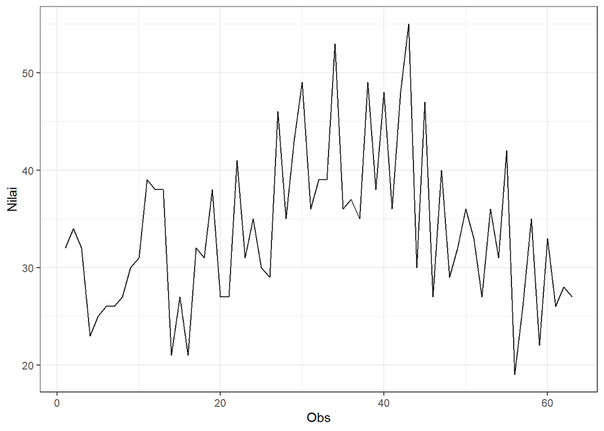

```r
dt_stas1 |> as_tsibble() |>
  ggplot(aes(x = index, y = value)) +
  geom_line() + theme_bw() +
  xlab("Obs") + ylab("Nilai")
```

Plot deret waktu di atas menunjukkan bahwa data tidak stasioner dalam rataan, ditandai dengan data yang tidak menyebar di sekitar suatu nilai tengah dan tidak stasioner dalam ragam, ditandai dengan lebar pita yang cenderung berbeda.

#### Plot ACF

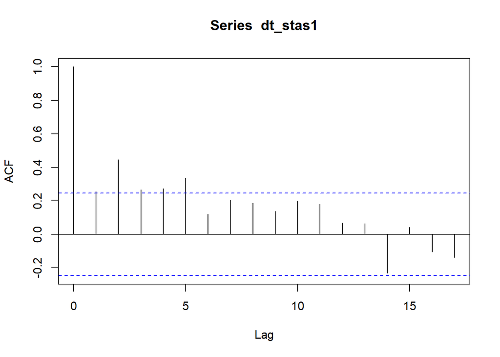

```r
acf(dt_stas1)
```

Berdasarkan plot ACF, terlihat bahwa plot ACF pada data tersebut cenderung *tails off* dengan lambat dan membentuk gelombang sinus. Artinya data hasil partisi yang pertama tidak stasioner dalam rataan.

#### Uji ADF

```r
tseries::adf.test(dt_stas1)
```

```
##
##  Augmented Dickey-Fuller Test
##
## data:  dt_stas1
## Dickey-Fuller = -1.8922, Lag order = 3, p-value = 0.6186
## alternative hypothesis: stationary
```

$H_0$ : Data tidak stasioner dalam rataan

$H_1$ : Data stasioner dalam rataan

Berdasarkan uji ADF tersebut, didapat *p-value* sebesar 0.6186 yang lebih besar dari taraf nyata 5% sehingga tidak tolak $H_0$ dan menandakan bahwa data tidak stasioner dalam rataan. Hal ini sesuai dengan hasil eksplorasi menggunakan plot time series dan plot ACF.

#### Plot Boxcox

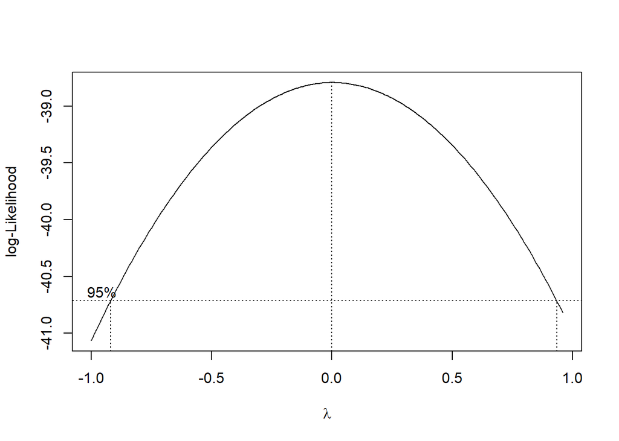

```r
index <- seq(1:63)
bc = boxcox(dt_stas1~index, lambda = seq(-1,0.96,by=0.01))
```

```r
#Nilai Rounded Lambda
lambda <- bc$x[which.max(bc$y)]
lambda
```

```
## [1] 0
```

```r
#SK
bc$x[bc$y > max(bc$y) - 1/2 * qchisq(.95,1)]
```

```
##   [1] -0.91 -0.90 -0.89 -0.88 -0.87 -0.86 -0.85 -0.84 -0.83 -0.82 -0.81 -0.80
##  [13] -0.79 -0.78 -0.77 -0.76 -0.75 -0.74 -0.73 -0.72 -0.71 -0.70 -0.69 -0.68
##  [25] -0.67 -0.66 -0.65 -0.64 -0.63 -0.62 -0.61 -0.60 -0.59 -0.58 -0.57 -0.56
##  [37] -0.55 -0.54 -0.53 -0.52 -0.51 -0.50 -0.49 -0.48 -0.47 -0.46 -0.45 -0.44
##  [49] -0.43 -0.42 -0.41 -0.40 -0.39 -0.38 -0.37 -0.36 -0.35 -0.34 -0.33 -0.32
##  [61] -0.31 -0.30 -0.29 -0.28 -0.27 -0.26 -0.25 -0.24 -0.23 -0.22 -0.21 -0.20
##  [73] -0.19 -0.18 -0.17 -0.16 -0.15 -0.14 -0.13 -0.12 -0.11 -0.10 -0.09 -0.08
##  [85] -0.07 -0.06 -0.05 -0.04 -0.03 -0.02 -0.01  0.00  0.01  0.02  0.03  0.04
##  [97]  0.05  0.06  0.07  0.08  0.09  0.10  0.11  0.12  0.13  0.14  0.15  0.16
## [109]  0.17  0.18  0.19  0.20  0.21  0.22  0.23  0.24  0.25  0.26  0.27  0.28
## [121]  0.29  0.30  0.31  0.32  0.33  0.34  0.35  0.36  0.37  0.38  0.39  0.40
## [133]  0.41  0.42  0.43  0.44  0.45  0.46  0.47  0.48  0.49  0.50  0.51  0.52
## [145]  0.53  0.54  0.55  0.56  0.57  0.58  0.59  0.60  0.61  0.62  0.63  0.64
## [157]  0.65  0.66  0.67  0.68  0.69  0.70  0.71  0.72  0.73  0.74  0.75  0.76
## [169]  0.77  0.78  0.79  0.80  0.81  0.82  0.83  0.84  0.85  0.86  0.87  0.88
## [181]  0.89  0.90  0.91  0.92  0.93
```

Gambar di atas menunjukkan nilai *rounded value* ($\lambda$) optimum sebesar **0** dan pada selang kepercayaan 95% nilai memiliki batas bawah **-0.91** dan batas atas ** 0.93**. Selang tersebut tidak memuat nilai satu sehingga dapat dikatakan bahwa data partisi bagian pertama tidak stasioner dalam ragam.

#### Bagian 2

```r
dt_stas2 <- die[1:120] |> ts()
mean(dt_stas2)
```

```
## [1] 32.93333
```

```r
var(dt_stas2)
```

```
## [1] 54.90308
```

#### Plot Time Series

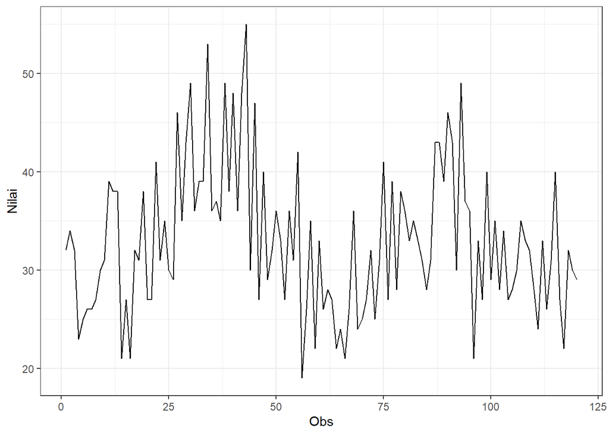

```r
dt_stas2 |> as_tsibble() |>
  ggplot(aes(x = index, y = value)) +
  geom_line() + theme_bw() +
  xlab("Obs") + ylab("Nilai")
```

Plot deret waktu di atas menunjukkan bahwa data tidak stasioner dalam rataan, ditandai dengan data yang tidak menyebar di sekitar nilai tengahnya dan tidak stasioner dalam ragam, ditandai dengan lebar pita yang cenderung berbeda.

#### Plot ACF

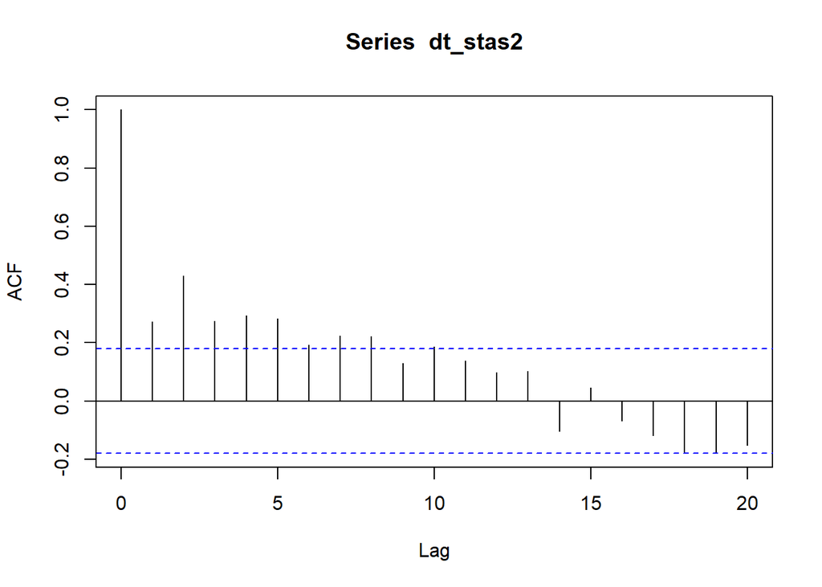

```r
acf(dt_stas2)
```

Berdasarkan plot ACF, terlihat bahwa plot ACF pada data tersebut cenderung *tails off* lambat dan membentuk gelombang sinus. Artinya data tidak stasioner dalam rataan.

#### Uji ADF

```r
adf.test(dt_stas2)
```

```
##
##  Augmented Dickey-Fuller Test
##
## data:  dt_stas2
## Dickey-Fuller = -2.6413, Lag order = 4, p-value = 0.3102
## alternative hypothesis: stationary
```

$H_0$ : Data tidak stasioner dalam rataan

$H_1$ : Data stasioner dalam rataan

Berdasarkan uji ADF tersebut, didapat *p-value* sebesar 0.3102 yang lebih besr dari taraf nyata 5% sehingga tidak tolak $H_0$ dan menandakan bahwa data tidak stasioner dalam rataan. Hal ini sesuai dengan hasil eksplorasi menggunakan plot time series dan plot ACF.

#### Plot Boxcox

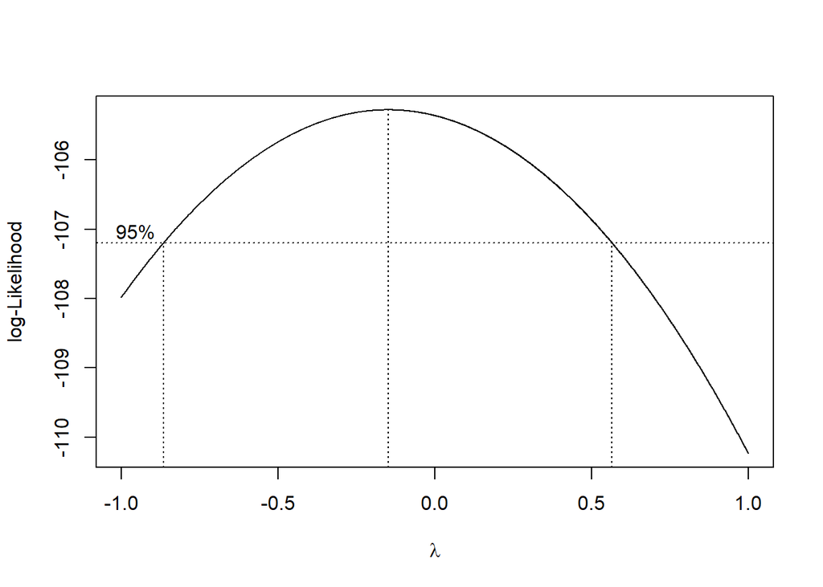

```r
index <- seq(1:120)
bc = boxcox(dt_stas2~index, lambda = seq(-1,1,by=0.001))
```

```r
#Nilai Rounded Lambda
lambda <- bc$x[which.max(bc$y)]
lambda
```

```
## [1] -0.149
```

```r
#SK
bc$x[bc$y > max(bc$y) - 1/2 * qchisq(.95,1)]
```

```
##    [1] -0.865 -0.864 -0.863 -0.862 -0.861 -0.860 -0.859 -0.858 -0.857 -0.856
##   [11] -0.855 -0.854 -0.853 -0.852 -0.851 -0.850 -0.849 -0.848 -0.847 -0.846
##   [21] -0.845 -0.844 -0.843 -0.842 -0.841 -0.840 -0.839 -0.838 -0.837 -0.836
##   [31] -0.835 -0.834 -0.833 -0.832 -0.831 -0.830 -0.829 -0.828 -0.827 -0.826
##   [41] -0.825 -0.824 -0.823 -0.822 -0.821 -0.820 -0.819 -0.818 -0.817 -0.816
##   [51] -0.815 -0.814 -0.813 -0.812 -0.811 -0.810 -0.809 -0.808 -0.807 -0.806
##   [61] -0.805 -0.804 -0.803 -0.802 -0.801 -0.800 -0.799 -0.798 -0.797 -0.796
##   [71] -0.795 -0.794 -0.793 -0.792 -0.791 -0.790 -0.789 -0.788 -0.787 -0.786
##   [81] -0.785 -0.784 -0.783 -0.782 -0.781 -0.780 -0.779 -0.778 -0.777 -0.776
##   [91] -0.775 -0.774 -0.773 -0.772 -0.771 -0.770 -0.769 -0.768 -0.767 -0.766
##  [101] -0.765 -0.764 -0.763 -0.762 -0.761 -0.760 -0.759 -0.758 -0.757 -0.756
##  [111] -0.755 -0.754 -0.753 -0.752 -0.751 -0.750 -0.749 -0.748 -0.747 -0.746
##  [121] -0.745 -0.744 -0.743 -0.742 -0.741 -0.740 -0.739 -0.738 -0.737 -0.736
##  [131] -0.735 -0.734 -0.733 -0.732 -0.731 -0.730 -0.729 -0.728 -0.727 -0.726
##  [141] -0.725 -0.724 -0.723 -0.722 -0.721 -0.720 -0.719 -0.718 -0.717 -0.716
```

[output cut: 129 more lines]